# Kapittel 10 og 11

# Kapittel 10: Grunnskole

# 10.1 Introduksjon

- Dette kapitlet, om grunnskoleutdanning, og det neste, om høyere utdanning, må ses i sammenheng.
- Ved hjelp av samme økonomisk teori når man forskjellige konklusjoner om statens rolle

## 10.2 Målene med grunnskoleutdanning

### Hovedmålet: å oppnå bedre utdanningsresultater

- å overføre
  - kunnskaper og ferdigheter, *og*
  - holdninger og verdier
- utdanning handler også om kultur
- Kilder til bedre utdanningsresultater:
  - inntekt / formue
  - individuelle valg
  - foreldre
  - medelever
  - innfødte evner
- utdanningsresultatene ikke bare avhengig av tilgang til utdanning

### Instrumentelle mål: Effektivitet og rettferdighet

- **Effektivitet**
  - Hvis vi ikke brukte noe penger på utdanning, ville folk ikke kunne lese
  - Hvis vi brukte hele BNP på utdanning, ville det ikke være mat, og vi ville dø av sult
  - Den optimale mengden av utdanning ligger et sted mellom
  - Makroeffektivitet
  - Mikroeffektivitet
  - Produksjonseffektivitet
- **Rettferdighet**
  - Ingen entydig definisjon
  - Rettferdighet anses å innebære at barn A og B skal ha **like** **muligheter** til å skaffe seg en utdanning av lik kvalitet
    - uavhengig av bakgrunn
    - like muligheter innebærer ikke nødvendigvis likhet i utfall av minst tre grunner:
      - A kan være heldigere enn B
      - A og B kan ha forskjellig smak
      - A kan være mer “dyktig” enn B (der slike forskjeller ikke er relatert til utdanningsmessige og sosiale forhold tidligere i livet)

## 10.2.2 Effektivitet: Måling av kostnader og nytte

- Måle kostnader: Gjennomførbart, men ikke uten problemer
- Nytte er vanskelig å kvantifisere: Hva er god utdanning?
  - ikke noe entydig svar –> ikke noe entydig mål
    - vi kan måle testresultater
      - testresultatene er ufullstendige indikatorer
    - Nytteeffektene med utdanning er veldig brede
      - konsumnytte
        - man kan nyte selve utdanningsprosessen
      - investeringsnytte
        - høyere lønn
        - større arbeidsglede
        - større nytelse av fritid
      - positive eksternaliteter
    - De fleste av disse er vanskelig å måle, men det gjør dem ikke mindre reelle

### Utdanning skaper positive eksternaliteter

- Økt innbetaling av skatt
- Raskere økonomisk vekst - min utdanning gjør også andre mer produktive
- Bedre respons på økonomisk endring
- Sterkere sosial samhørighet
- Bedre foreldre
- Bra for demokrati

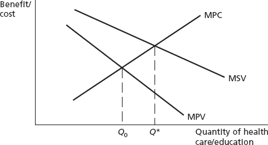

## Måleutfordringer

- Det er vanskelig å etablere sammenheng mellom innsatsfaktorer og resultater
  - mulig å måle innsatsfaktorers kvantitet, men ikke kvalitet
  - umulig å måle mange andre faktorer (innfødte evner, kvalitet av undervisning, kvalitet på foreldrene osv.)
- Årsakssammenheng kan ikke fastslås
  - Screeninghypotesen stiller spørsmål ved årsakssammenhengen mellom høyere utdaning og økt individuell produktivitet
    - Er en person produktiv fordi hen har innfødte evner, eller fordi hen har blitt godt utdannet?

## 10.2.3 Måling av fordelingseffektene av grunnskoleutdanning

- Skatter
  - Er grunnskoleutdanning finansiert progressivt?
  - Utjevner “gratis” skolegang alle forskjellene når det gjelder tilgang?
- Livsløps- og intergenerasjonelle effekter
  - Betydningen av utviklingen i tidlig barndom
  - Utdanningsmessig ulikhet påvirker ikke bare den enkelte, men har også intergenerasjonelle effekter

## 10.3.1 Teoretiske argumenter for offentlig inngrep 1: effektivitet

### Informasjonsproblemer, atferdsproblemer og ufullstendige markeder

- Informasjonsproblemer: Er skoleelever godt informert om “produktets” art, om priser og framtiden?
  - Barn er ikke godt informert
  - Kostnaden for feile valg kan være høy
- Rasjonell adferd?
  - foreldre vil kanskje ikke ta hensyn til barnets beste, men familiens beste (lav konsumentsuverenitet)
- Manglende markeder og ufullstendige kontrakter
  - Produktets kompleksitet
    - vanskelig å spesifisere i kontrakt
  - Markedet for utdanningsfinansiering er imperfekt, ikke minst fordi studenter som ønsker å låne ikke kan tilby fysisk eller økonomisk sikkerhet
- I et rent markedssystem vil dette føre til underforbruk, særlig for lavere samfunssøkonomiske grupper
- Ufullkommen konkurranse
  - Skoler i byer kan ha konkurranse, men en rural skole kan ha et lokalt monopol –> underproduksjon
    - prisregulering
- Positive eksternaliteter –> underforbruk
  - utdanning vil både gi eleven privat nytte,og nytte for samfunnet
    - subsidiering
  - disse eksternalitetene kan være vanskelige å kvantifisere, men er høyest reelle

## 10.3.2 Teoretiske argumenter for offentlig inngrep 2: rettferdighet

- horisontal likhet
  - foreldre fra lavere sosioøkonomiske grupper kan ha mindre informasjon om skolevalg
  - de kan også være mindre i stand til å bruke denne informasjonen
  - “lik tilgang til utdanning”
- vertikal likhet
  - handler om i hvilken grad grunnskoleutdanningen burde omfordele inntekt fra rike til fattige

## 10.3.3 Ulike typer av inngrep

- **Rent privat tilbud? Nei**
  - markedssvikt
    - informasjonsproblemer
      - obligatorisk skolepliktig alder
      - læreplan
      - kvalifikasjonskrav for lærere
      - skolegodkjenninger
    - ikke-rasjonelle aktører
      - private konsumvalg er effektive og rettferdige bare hvis familier har tilstrekkelig informasjon og om de bruker denne informasjonen til barnets beste
      - noen familier er i stand til å gjøre bedre valg for sine barn enn staten, noen er ikke det
        - er valgene knyttet til familiens sosioøkonomisk status?
    - ufullstendige kontrakter -regulering
    - positive eksternaliteter - subsidier
    - ufullkomne kapitalmarkeder -subsidier
- **Offentlig produksjon, allokering og finansiering? Ja**
  - Disse problemene dreier seg avgjørende om svarene på to spørsmål
    - Gjør foreldre bedre eller dårligere beslutninger enn staten om barnas utdanning?
      - svaret til dette spørsmålet er empirisk
    - Hvis kvaliteten på foreldrenes valg varierer systematisk med sosioøkonomisk status, hvordan vekter vi kravene til middelklassebarn og deres foreldre om å ha valgmuligheter, i forhold til kravene til barn fra lavere sosioøkonomiske grupper, hvis interesser kan være bedre tjent av staten?
      - libertarianere:
        - hevder at statlig allokering forstyrrer foreldrenes frihet
      - sosialister:
        - målet om likhet er overordnet
          - kravet fra barn fra fattigere familier prioriteres
        - statlig allokering foretrekkes både for å sikre at barn med dårligere bakgrunn går på en god skole og for å sikre en elevsammensetning som oppmuntrer til utdanning og fremmer sosialt samhold
      - liberale
        - prøver å anerkjenne kravene til begge grupper
        - et system enten basert på offentlig allokering, som tar noe hensyn til foreldrenes preferanser, eller basert på foreldrenes valg som overvåkes nøye

## Lærdommer fra økonomisk teori

- Markedssviktene i grunnskoleutdanningen er tilstrekkelig store til å gjøre offentlig produksjon, allokering og finansiering av grunnskoleutdanning til en holdbar strategi av effektivitetsgrunner
- Det er også hensiktsmessig å finansiere utdanning omfordelende av hensyn til sosial rettferdighet

## Utdanning er ikke homogen

- utdanning ikke er en homogen enhet
- vil svarene for grunnskoleutdanning gjelde for alle typer utdanning?
  - er svarene like for obligatorisk grunnskoleutdanning og høyere utdanning?
  - bør noen typer utdanning være gratis og andre ikke?
  - er markedsløsninger mer anvendelige for høyere utdanning enn for skoleutdanning?
  - skal høyere utdanning delvis finansieres med lån og i så fall på hvilke vilkår skal lånet gis eller tilbakebetales?

# Kapittel 11: Høyere utdanning

## Hvor er vi?

- Kapittel 10: offentlig finansiering og (i veldig stor grad) offentlig produksjon av grunnskoleutdanning
- Dette kapitlet anvender den samme teorien på høyere utdanning og når svært forskjellige konklusjoner
- argumentene kan også brukes til å se på videreutdanning og livslag læring

## 11.1 Introduksjon

- Med samme teori som forrige kapittel konkluderer dette kapittelet med at
  - finansiering av høyere utdanning bør deles mellom skattebetaler og -mottaker
  - produksjon og allokering bør gjennomføres gjennom regulerte markedskrefter

## 11.2 Mål

- Hovedmål
  - å overføre
    - kunnskaper og ferdigheter
    - holdninger og verdier
  - å fremme
    - intellektuell frihet og mangfold
    - jakten på kunnskap for sin egen skyld
- Instrumentelle mål
  - Effektivitet
    - makro
    - mikro
    - produksjonseffektivitet
  - Rettferdighet
    - like muligheter

## Spefisikke mål for høyere utdanning

- idéfrihet
- kvalitet
- tilgang
  - rettferdighet
  - effektivitet
- størrelse

## 11.3.1 Teoretiske argumenter for offentlig inngrep 1: Effektivitet

- ufullkommen informasjon?
  - jo mer konsumentsuverenitet i høyere utdanning
    - jo mer informasjon forbrukere har
    - jo billigere og mer effektivt informsjon kan forbedres
    - jo lettere det er å forstå tilgjengelig informasjon
    - jo lavere er kostnadene ved et feilvalg
    - jo mer forskjellig preferansene er
  - desto mer sannsynlig er det at studentene gjør bedre valg for seg selv enn staten hadde gjort
  - studentene er velinformerte konsumenter
    - det er mer konsumentsuverenitet i høyere utdanning enn i grunnskoleutdanning
- imperfekt konkurranse?
  - mange universiteter og høyskoler
  - elevene kan bo hjemmefra
  - fjernundervisning
  - mer konkurranse i høyere utdanning enn i grunnskoleutdanning
- eksternaliteter i form av
  - Økt innbetaling av skatt
  - Raskere økonomisk vekst - min utdanning gjør også andre mer produktive
  - Bedre respons på økonomisk endring
  - Sterkere sosial samhørighet
  - Bedre foreldre
  - Bra for demokrati
- **men også betydelig privat nytte**
  - det er både effektivt og rettferdig at kostnader ved høyere utdanning deles:
    - skattbetalerne subsidierer
    - “brukerbetaling”

## Hvorfor studielån?

- Eksternalitetsargumentet
  - Det er mest effektivt å dele kostnader mellom skattebetalerne (ekstern nytte) og studenten (privat nytte)
- Finansieringsargumentet
  - Høyere utdanning konkurrerer om ressurser med (f.eks.) pensjoner og helsetjenester
- Fordelingsargumentet
  - Siden fleste studenter er fra høyere samfunnslag, vil bare skattefinansiert høyere utdanning fungere regressivt

## Hvilken type lån?

- Boliglånsaktige lån: fast tilbakebetaling på x antall kroner per måned til lånet er tilbakebetalt.
- Inntektsavhengige lån: Tilbakebetaling av x% av månedslønn til lånet er nedbetalt.
- skatt for uteksaminerte: Betaling av x% av inntektene til pensjonering.

## Hvorfor ikke finansiere studier med vanlig lån?

- Mangelen på sikkerhet er årsaken til det imperfekte markedet for studielån
- Når noen kjøper et hus
  - hen vet hva hen kjøper
  - det er lite sannsynlig at huset faller sammen
  - verdien av huset vil sannsynligvis gå opp
  - hvis lånetakerens inntekt faller uventet, kan han vanligvis selge huset for å betale tilbake lånet
- Når noen låner for en utdanning
  - De kan være dårlig informert om produktets natur, spesielt hvis de kommer fra en familie uten akademikere
  - Det er en høy risiko (eller i det minste en oppfattet høy risiko, som igjen er høyere for personer uten tidligere universitetserfaring i familien) for å vikke bli ferdig
  - Selv om gjennomsnittlig privat avkastning for utdanning er positiv, er det betydelig variasjon rundt den
  - Det er ingen sikkerhet for lånet
    - hvis låntakerens inntekt faller uventet, er det ingen mulighet til å selge graden for å betale tilbake lånet

## 11.3.1 Teoretiske argumenter for offentlig inngrep 2: Rettferdighet

- En person med vanskeligstilt bakgrunn er mer sannsynlig
  - å bli dårlig informert om fordelene ved å gå på universitetet
  - å gjøre det mindre bra når det gjelder livsløps- og intergenerasjonelle effekter
  - å gå på en dårligere skole
- Dermed har staten en betydelig rolle i å fremme gjøre tidlige inngrep
  - forbedre informasjon
  - forbedre grunnskoleutdanningen
  - gi økonomisk hjelp

## Ulike typer inngrep

- Gruunskoleutdanning vs. høyere udanning: to svært forskjellige strategier
- Tre viktige forskjeller
  - Alder
    - Etter hvert som elevene blir eldre, blir de bedre informert (konsumentsuverenitet)
      - Dermed er en universitetsstudent generelt bedre informert enn noen andre om hans eller hennes behov.
  - Mangfold
    - Det er sterke argumenter for homogenitet i emnene grunnskolen tilbyr
      - felles kunnskapsbase
      - felles verdier (sosial kohesjon)
    - Jo høyere opp i utdanningsskalaen, jo større er ønsket om mangfold av fagstoff
  - Sosioøkonomisk status
    - Det er betydelig forskjeller i tilgang til skolegang av høy kvalitet og til informasjon om fordelene med en utdanning
    - Dermed er det hovedsakelig folk fra høyere samfunnslag som går på universitetet

## Lærdommer fra økonomisk teori

- Konkurranse i høyere utdanning, passende regulert, er fordelaktig
  - Empirisk ser det ut til at konkurrerende systemer for høyere utdanning gir høyere kvalitet, i det minste målt ved verdensrangeringer
- Nyutdannede (ikke studenter) bør bidra til kostnadene for utdanning
  - høyere utdanning skaper en rekke positive eksternaliteter, som rettferdiggjør fortsatt støtte fra skattebetalerne
  - uteksaminerte får vanligvis også privat nytte
    - høyere inntekt, mer tilfredsstillende jobber, større glede av fritiden – noe som gjør det effektivt og rettferdig at de bærer en del av kostnadene.
    - de bør bære disse kostnadene når de har råd til dem, som uteksaminerte, ikke når de er studenter.